# Experimental ‘Odds of Test’ Models

Project: Diagnostic Growth UEC

Published

September 24, 2024

# 1 Introduction

Having settled on our “ecds_only” data sample (containing 16 providers), we will build a basic, experimental, case-mix adjusted “odds of test” model. A model of this type will be used to address project Question 2:

For each test type, how much more likely is it that a patient will receive the test in ED in 2023/24 compared to 2019/20?

This document outlines some of the thought processes and questions we had during this model building exercise.

# 2 Preparing the data

From the data set summary report, we know that our sample of the “ecds_only” table, based on provider data quality, contains measurements of 38 variables for about 3 million ED attendances across 16 providers.

## 2.1 Variables: treatment and removal

Using the *is_march* variable, we have removed attendances in March from both 2020 and 2024 to avoid any bias that may arise due to the onset of the pandemic in March 2020. We then removed the *is_march* variable.

Over 96% of values for *number of comorbidities* variable are zero. (This seems improbable and was therefore deemed to be a quality issue?) This variable has therefore been ignored.

We have added time-related variables (month, weekday, and hour of attendance, as well as binary variables, is_winter, is_wkend, and is_night).

### 2.1.1 Diagnosis codes and causality

As mentioned in an earlier document, it was our intention to use *acuity*, c*hief complaint group* and the *injury flag* (which is derived from *chief complaint* (ungrouped)), rather than the lower quality diagnoses fields.

Must we also consider that a *diagnosis is often the result of testing*? (Is it therefore valid to use diagnosis codes as a predictor of whether a patient will receive a test?) If we were to rule out the use of diagnosis codes on this basis, we must also rule out use of *number of diagnoses,* as proxy for number of commodities.

### 2.1.2 Chief complaint group

This leaves us with the *chief complaint* or *chief complaint group* fields, which have 146 and 15 categories, respectively. The values of *chief complaint (description)* should be akin to presentation codes - vague enough that they should reflect a clinician’s initial observation, yet detailed enough to be informative. We re-engineered the original variable, reducing the 146 levels down to 84 (by grouping levels that are rare (occurring in <1 in 600 attendances) in the dataset).

## 2.2 Missing Values: treatment

It’s likely that we will rely on a logistic regression model of some description, and this model type will not accept missing values. In the interests of time, we have, by default, decided to delete records with missing values for any of the variables. This approach will reduce our sample size, increase the standard error of our model coefficients, and could feasibly bias these coefficients if the data are not missing completely at random. These risks may be mitigated (and our approach may be easier to justify) given that records have already been vetted for high levels of completeness. In any case, the table, below, shows the variables implicated.

| Variable | Approx no. missing values |
| --- | --- |
| Chief complaint group | 80,000 |
| Acuity | 40,000 |
| Injury flag | 30,000 |
| Der investigation all | 12,000 |
| IMD decile | 500 |
| Age | 100 |

These groups are not mutually exclusive, so the result of deleting all records with missing values is that we lose 3.6% (113k) records.

## 2.3 Outcome Variable: Treatment

In what follows, we’ve used EC-style (SNOMED?) investigation codes, rather than AEA-style codes, as in the past, on the assumptions that EC-style codes:

- Better reflect current tests and current practice
- Are more specific about the test being conducted
- Are likely to be more future-proof

There are 48 different EC investigations (removing the code for no investigation stated). These are numbered from 50 to 97 (presumably to avoid overlap with AEA-style numbering). For reference, there were around 20 (valid) AEA investigation types. Note: It should be relatively simple to map EC to AEA codes and/or run models for AEA-style codes, if necessary.

Some of the EC-style tests are provided infrequently (they have a low event rate) which will make them more difficult to visualise and model than those with a higher event rate. We may wish to create an “other test” category which could contain, for example, tests conducted in less than 1 in 250 ED attendances.

Figure 1 shows that if we set the threshold at 1/250, we will still have a number of tests with a relatively low event rate that don’t fall into this “other” category. This is something to remain aware of, since most models will overfit to the majority class. When that majority class contains the vast majority of observations, models will be poorly calibrated. [Subsampling](https://www.tidymodels.org/learn/models/sub-sampling/) is a potential solution.

Figure 1: Appearance of each test type, by financial year

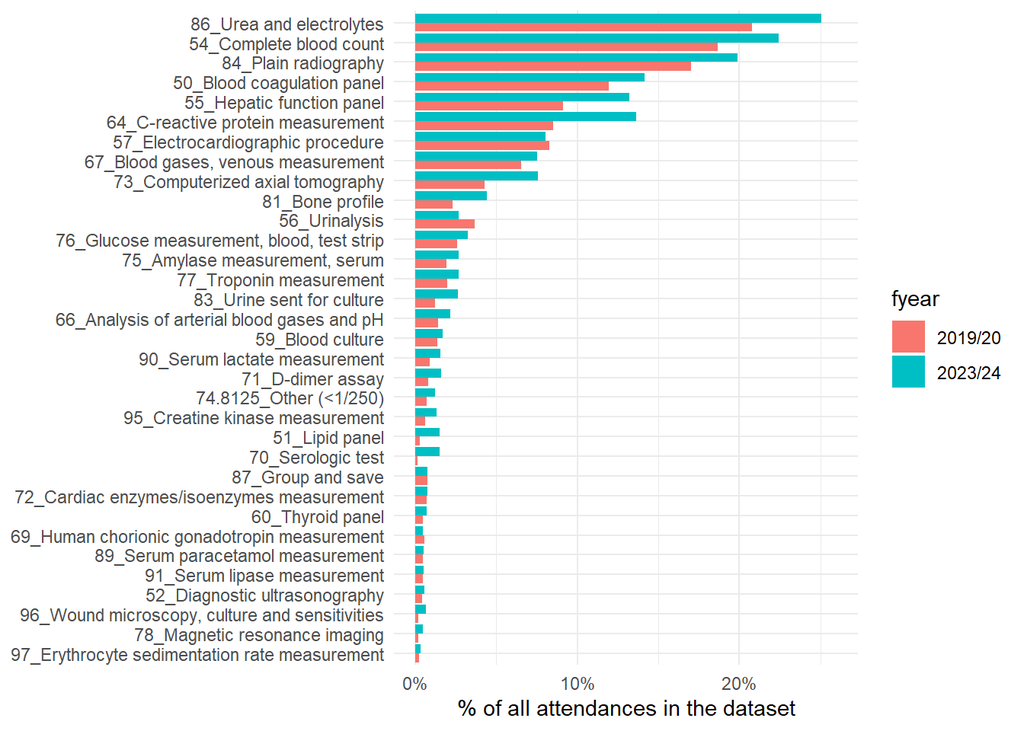

# 3 Building the models

In the following examples, we will examine whether the odds of a patient receiving a **CT test** have changed between 2019/20 and 2023/24. We will employ a Generalised Additive Model (GAM) from the `mgcv` package, using a sample of 10% of the data set (~300k records).

For this first attempt at a model, Model 1, we will use *chief complaint group* (15 levels) together with the *injury flag* in our case-mix adjustment. We will exclude *attendance source* and *ethnic group,* which might ultimately contain useful information*.* (Note that we checked that we had no near-zero variance or highly correlated ( r > 0.7) predictors, both of which are undesirable when performing logistic regression.) The full model specification for Model 1 was:

```r
mgcv::gam(
  formula = invst_73 ~ fyear +
    ## DEMOGRAPHICS ######
    s(age) + sex + imd_dec +
    ## CASE-MIX-RELATED ##
    arr_mode + acuity + chief_comp_grp + inj_flag +
    ## TIME-RELATED ######
    month + wkday + hour,
  family = "binomial",
  data = demo_processed
  )
```

We will also specify a second model, Model 2, in which we will replace chief complaint group with the (engineered) *chief complaint (description)*, which has 84 levels. This also makes the *injury flag* redundant. At the same time we will remove weekday and hour.

```r
mgcv::gam(
  formula = invst_73 ~ fyear +
    ## DEMOGRAPHICS ######
    s(age) + sex + imd_dec +
    ## CASE-MIX-RELATED ##
    arr_mode + acuity + chief_comp_desc +
    ## TIME-RELATED ######
    month,
  family = "binomial",
  data = demo_processed
  )
```

# 4 Results

Model 1 and Model 2 had adjusted R squared values of 0.18 and 0.25, respectively. Model coefficients can be seen in the tabs below. Model 1 indicates that, having adjusted for case-mix, the odds of receiving a CT scan in 2023/24 were 1.78 times higher than the odds in 2019/20. For Model 2, the estimate was 1.77. In both cases, these coefficients were highly significant.

**Model 1**

| term | odds | estimate | statistic | p.value | sig |
| --- | --- | --- | --- | --- | --- |
| (Intercept) | 0.0284 | -3.5624 | -58.1015 | 0.0000 | *** |
| fyear2023/24 | 1.7823 | 0.5779 | 43.5758 | 0.0000 | *** |
| sexm | 1.1450 | 0.1354 | 10.6256 | 0.0000 | *** |
| imd_dec10 | 1.0395 | 0.0387 | 1.3088 | 0.1906 |  |
| imd_dec2 | 0.9952 | -0.0049 | -0.1985 | 0.8427 |  |
| imd_dec3 | 1.0213 | 0.0211 | 0.8496 | 0.3956 |  |
| imd_dec4 | 1.0191 | 0.0189 | 0.7413 | 0.4585 |  |
| imd_dec5 | 1.0169 | 0.0168 | 0.6427 | 0.5204 |  |
| imd_dec6 | 1.0412 | 0.0404 | 1.5418 | 0.1231 |  |
| imd_dec7 | 1.0228 | 0.0226 | 0.8465 | 0.3973 |  |
| imd_dec8 | 1.0076 | 0.0075 | 0.2732 | 0.7847 |  |
| imd_dec9 | 0.9729 | -0.0275 | -0.9873 | 0.3235 |  |
| arr_modewalk_in | 0.5109 | -0.6716 | -45.1085 | 0.0000 | *** |
| acuity.L | 0.1743 | -1.7472 | -24.8270 | 0.0000 | *** |
| acuity.Q | 0.8010 | -0.2219 | -3.7468 | 0.0002 | *** |
| acuity.C | 0.9226 | -0.0805 | -2.1679 | 0.0302 | * |
| acuity^4 | 1.1497 | 0.1395 | 7.9531 | 0.0000 | *** |
| chief_comp_grpCirculation / chest | 1.7609 | 0.5658 | 17.4694 | 0.0000 | *** |
| chief_comp_grpEnvironmental | 0.4551 | -0.7873 | -6.6747 | 0.0000 | *** |
| chief_comp_grpEye | 2.7601 | 1.0153 | 14.4184 | 0.0000 | *** |
| chief_comp_grpGastrointestinal | 3.4713 | 1.2445 | 38.3985 | 0.0000 | *** |
| chief_comp_grpGeneral / minor / admin | 2.4314 | 0.8885 | 26.2527 | 0.0000 | *** |
| chief_comp_grpGenitourinary | 2.1040 | 0.7438 | 16.1719 | 0.0000 | *** |
| chief_comp_grpHead and neck | 1.7257 | 0.5457 | 9.7632 | 0.0000 | *** |
| chief_comp_grpNeurological | 11.8277 | 2.4704 | 80.9044 | 0.0000 | *** |
| chief_comp_grpNot applicable to child terms | 3.0401 | 1.1119 | 19.6555 | 0.0000 | *** |
| chief_comp_grpObGyn | 0.1454 | -1.9285 | -7.3940 | 0.0000 | *** |
| chief_comp_grpPsychosocial / Behaviour change | 1.2795 | 0.2465 | 4.4109 | 0.0000 | *** |
| chief_comp_grpSkin | 0.4605 | -0.7755 | -11.4426 | 0.0000 | *** |
| chief_comp_grpTrauma / musculoskeletal | 2.3184 | 0.8409 | 23.3505 | 0.0000 | *** |
| inj_flag1 | 2.6157 | 0.9615 | 37.8097 | 0.0000 | *** |
| month10 | 0.9521 | -0.0491 | -1.6938 | 0.0903 |  |
| month11 | 0.9469 | -0.0545 | -1.8669 | 0.0619 |  |
| month12 | 0.9775 | -0.0228 | -0.7930 | 0.4278 |  |
| month2 | 0.9679 | -0.0326 | -1.1148 | 0.2649 |  |
| month4 | 0.8860 | -0.1211 | -4.0704 | 0.0000 | *** |
| month5 | 0.8797 | -0.1282 | -4.3875 | 0.0000 | *** |
| month6 | 0.8691 | -0.1403 | -4.7606 | 0.0000 | *** |
| month7 | 0.8975 | -0.1081 | -3.7187 | 0.0002 | *** |
| month8 | 0.8668 | -0.1430 | -4.9147 | 0.0000 | *** |
| month9 | 0.9364 | -0.0657 | -2.2653 | 0.0235 | * |
| wkdayMon | 0.9911 | -0.0089 | -0.3844 | 0.7007 |  |
| wkdaySat | 0.9712 | -0.0293 | -1.2183 | 0.2231 |  |
| wkdaySun | 0.9572 | -0.0438 | -1.8310 | 0.0671 |  |
| wkdayThu | 0.9819 | -0.0183 | -0.7783 | 0.4364 |  |
| wkdayTue | 0.9699 | -0.0306 | -1.3014 | 0.1931 |  |
| wkdayWed | 0.9868 | -0.0133 | -0.5634 | 0.5732 |  |
| hour1 | 0.9767 | -0.0236 | -0.4045 | 0.6858 |  |
| hour10 | 0.9047 | -0.1002 | -2.0973 | 0.0360 | * |
| hour11 | 0.9535 | -0.0476 | -1.0120 | 0.3116 |  |
| hour12 | 0.9934 | -0.0066 | -0.1411 | 0.8878 |  |
| hour13 | 0.9794 | -0.0208 | -0.4399 | 0.6600 |  |
| hour14 | 0.9470 | -0.0545 | -1.1437 | 0.2527 |  |
| hour15 | 0.9205 | -0.0828 | -1.7334 | 0.0830 |  |
| hour16 | 0.9226 | -0.0806 | -1.6838 | 0.0922 |  |
| hour17 | 0.9497 | -0.0516 | -1.0854 | 0.2778 |  |
| hour18 | 0.9406 | -0.0612 | -1.2698 | 0.2042 |  |
| hour19 | 0.9154 | -0.0884 | -1.7898 | 0.0735 |  |
| hour2 | 1.0590 | 0.0574 | 0.9276 | 0.3536 |  |
| hour20 | 0.9038 | -0.1011 | -2.0431 | 0.0410 | * |
| hour21 | 0.8991 | -0.1064 | -2.1077 | 0.0351 | * |
| hour22 | 0.9155 | -0.0883 | -1.7036 | 0.0884 |  |
| hour23 | 0.9419 | -0.0598 | -1.1069 | 0.2683 |  |
| hour3 | 1.0699 | 0.0675 | 1.0828 | 0.2789 |  |
| hour4 | 1.0042 | 0.0042 | 0.0675 | 0.9462 |  |
| hour5 | 0.8853 | -0.1218 | -1.9754 | 0.0482 | * |
| hour6 | 0.8520 | -0.1602 | -2.4354 | 0.0149 | * |
| hour7 | 0.9463 | -0.0552 | -0.8992 | 0.3686 |  |
| hour8 | 0.9206 | -0.0827 | -1.5641 | 0.1178 |  |
| hour9 | 0.8950 | -0.1109 | -2.2596 | 0.0238 | * |

**Model 2**

| term | odds | estimate | statistic | p.value | sig |
| --- | --- | --- | --- | --- | --- |
| (Intercept) | 0.1084 | -2.2220 | -51.6544 | 0.0000 | *** |
| fyear2023/24 | 1.7747 | 0.5736 | 40.6421 | 0.0000 | *** |
| sexm | 1.1397 | 0.1308 | 9.7634 | 0.0000 | *** |
| imd_dec10 | 1.0243 | 0.0240 | 0.7724 | 0.4399 |  |
| imd_dec2 | 0.9912 | -0.0088 | -0.3448 | 0.7303 |  |
| imd_dec3 | 1.0151 | 0.0150 | 0.5770 | 0.5640 |  |
| imd_dec4 | 1.0181 | 0.0179 | 0.6693 | 0.5033 |  |
| imd_dec5 | 1.0212 | 0.0210 | 0.7697 | 0.4415 |  |
| imd_dec6 | 1.0416 | 0.0408 | 1.4872 | 0.1370 |  |
| imd_dec7 | 1.0353 | 0.0347 | 1.2421 | 0.2142 |  |
| imd_dec8 | 1.0169 | 0.0167 | 0.5802 | 0.5618 |  |
| imd_dec9 | 0.9557 | -0.0453 | -1.5531 | 0.1204 |  |
| arr_modewalk_in | 0.5414 | -0.6136 | -39.1240 | 0.0000 | *** |
| acuity.L | 0.2104 | -1.5588 | -21.4596 | 0.0000 | *** |
| acuity.Q | 0.8530 | -0.1589 | -2.6016 | 0.0093 | ** |
| acuity.C | 0.9417 | -0.0601 | -1.5638 | 0.1179 |  |
| acuity^4 | 1.0936 | 0.0895 | 4.8961 | 0.0000 | *** |
| chief_comp_descAsthenia (finding) | 0.6242 | -0.4713 | -12.7893 | 0.0000 | *** |
| chief_comp_descAsymptomatic (finding) | 0.5470 | -0.6033 | -4.2686 | 0.0000 | *** |
| chief_comp_descBackache (finding) | 0.5397 | -0.6167 | -11.9843 | 0.0000 | *** |
| chief_comp_descBite - wound (disorder) | 0.0144 | -4.2392 | -5.9861 | 0.0000 | *** |
| chief_comp_descBizarre behavior (finding) | 0.7049 | -0.3497 | -3.3864 | 0.0007 | *** |
| chief_comp_descBleeding from vagina (finding) | 0.0617 | -2.7860 | -9.5547 | 0.0000 | *** |
| chief_comp_descBlood in feces symptom (finding) | 0.2097 | -1.5621 | -7.6844 | 0.0000 | *** |
| chief_comp_descBlood in urine (finding) | 0.3623 | -1.0152 | -10.2530 | 0.0000 | *** |
| chief_comp_descBurn (disorder) | 0.0865 | -2.4470 | -7.6252 | 0.0000 | *** |
| chief_comp_descChest injury (disorder) | 1.7570 | 0.5636 | 9.0667 | 0.0000 | *** |
| chief_comp_descChest pain (finding) | 0.2707 | -1.3068 | -39.8749 | 0.0000 | *** |
| chief_comp_descClouded consciousness (finding) | 2.0639 | 0.7246 | 15.8964 | 0.0000 | *** |
| chief_comp_descComplaining of feeling depressed (finding) | 0.3154 | -1.1539 | -7.6912 | 0.0000 | *** |

[output cut: 80 more lines]

## 4.1 Possible improvements

- Arrival source may contain useful information.
- Interactions? e.g. acuity may have a different effect on chances of test for each chief complaint. Age may have different effect on chances of test for each group of chief comp, arrival mode, acuity?
- …?

# 5 Other reflections

- What size sample to use for these models? 500k?
- Stick with GAMs or try glmnet or something else?
- Do we wish to look at whether the odds of a patient receiving all types of test (aggregated) has changed in this time?
- Could be of interest to model likelihood of two or more tests of same type?

# 6 Update following feedback (01 Oct)

- Reference level for *Chief Complaint* set as “chest pain”.
- Removed IMD - not significant and no change to coefficients
- Tried *is_winter* (months Dec to March). Seems useful.
- On the other hand, *is_night* (tried a few different intervals) and *is_wkend* did not appear to be helpful.
- TODO *procode* as random effect. Didn’t have time to implement but quickly found [this](https://r.qcbs.ca/workshop08/book-en/introduction-to-generalized-additive-mixed-models-gamms.html) and [this](https://fromthebottomoftheheap.net/2021/02/02/random-effects-in-gams/), which may or may not be helpful.
- TODO Unadjusted model. Should be easy to do.
- TODO larger sample size. 1 million?

So, current working model looks like:

```r
 mgcv::gam(
      formula = invst ~
        # VAR OF INTEREST:
        fyear +
        # DEMOGRAPHICS:
        s(age) + sex + # imd_dec +
        # CASE-MIX-RELATED:
        arr_mode + acuity + chief_comp_desc +
        # TIME-RELATED:
        is_winter +
        # PROVIDER (TODO: RANDOM EFFECT):
        procode,
      family = "binomial",
      data = df
    )
```